# Network visualization with R

Force-directed layouts try to get a nice-looking graph where edges are similar in length and cross each other as little as possible. They simulate the graph as a physical system. Nodes are electrically charged particles that repulse each other when they get too close. The edges act as springs that attract connected nodes closer together. As a result, nodes are evenly distributed through the chart area, and the layout is intuitive in that nodes which share more connections are closer to each other. The disadvantage of these algorithms is that they are rather slow and therefore less often used in graphs larger than ~1000 vertices.

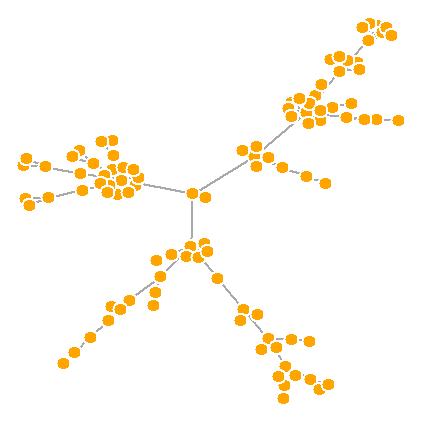

```r
l <- layout_with_fr(net.bg)
plot(net.bg, layout=l)
```

With force-directed layouts, you can use the `niter` parameter to control the number of iterations to perform. The default is set at 500 iterations. You can lower that number for large graphs to get results faster and check if they look reasonable.

```r
l <- layout_with_fr(net.bg, niter=50)
plot(net.bg, layout=l)
```

[output not shown]

The layout can also interpret edge weights. You can set the “weights” parameter which increases the attraction forces among nodes connected by heavier edges.

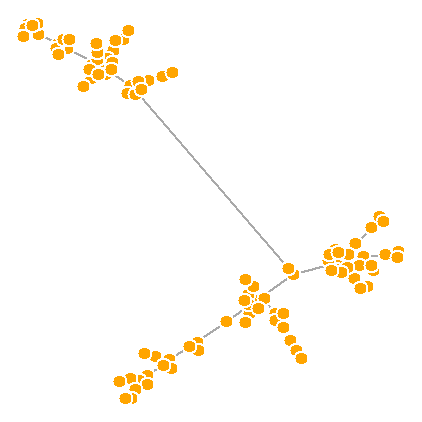

```r
ws  <-  c(1, rep(100, ecount(net.bg)-1))
lw <- layout_with_fr(net.bg, weights=ws)
plot(net.bg, layout=lw)
```

You will also notice that the Fruchterman-Reingold layout is not deterministic - different runs will result in slightly different configurations. Saving the layout in `l` allows us to get the exact same result multiple times, which can be helpful if you want to plot the time evolution of a graph, or different relationships – and want nodes to stay in the same place in multiple plots.

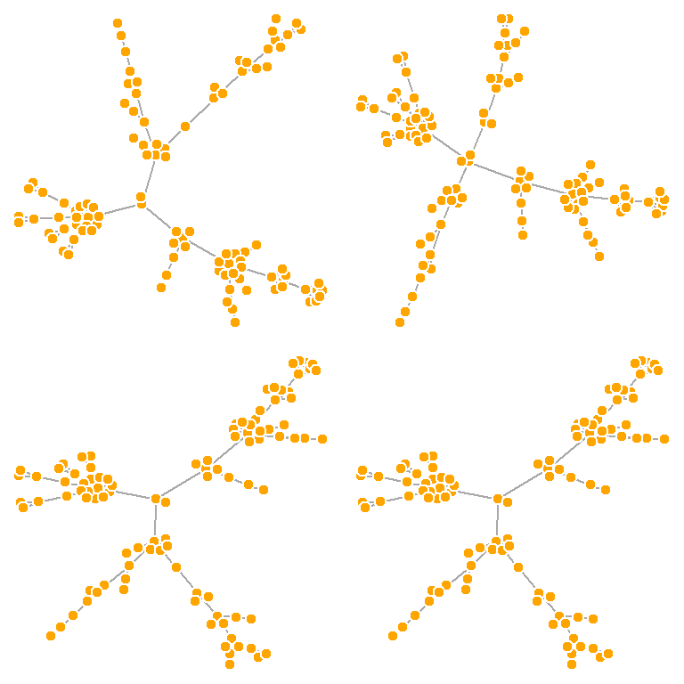

```r
par(mfrow=c(2,2), mar=c(0,0,0,0))   # plot four figures - 2 rows, 2 columns
plot(net.bg, layout=layout_with_fr)
plot(net.bg, layout=layout_with_fr)
plot(net.bg, layout=l)
plot(net.bg, layout=l)
```

```r
dev.off()
```

By default, the coordinates of the plots are rescaled to the [-1,1] interval for both x and y. You can change that with the parameter `rescale=FALSE` and rescale your plot manually by multiplying the coordinates by a scalar. You can use `norm_coords` to normalize the plot with the boundaries you want. This way you can create more compact or spread out layout versions.

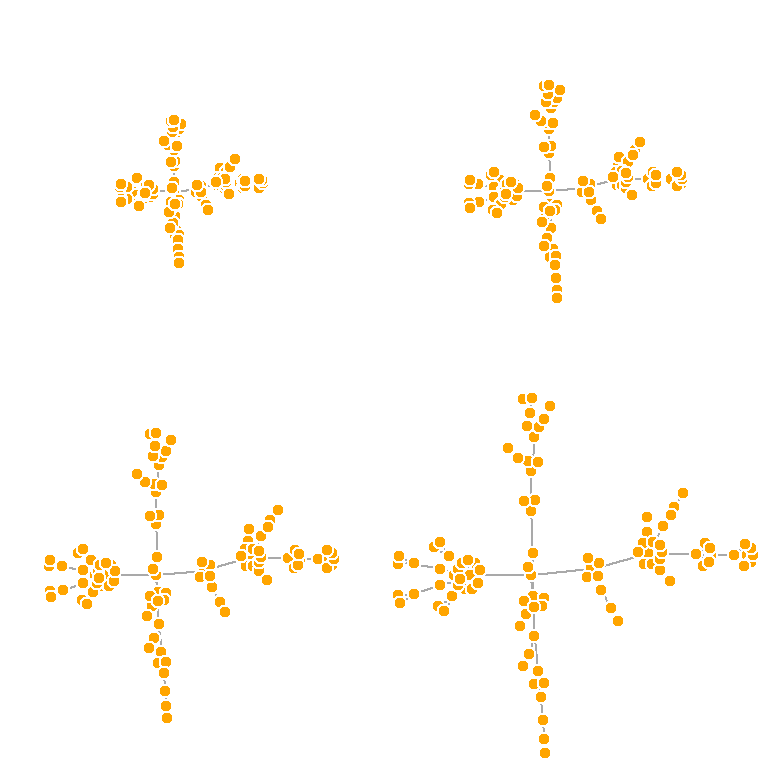

```r
l <- layout_with_fr(net.bg)
l <- norm_coords(l, ymin=-1, ymax=1, xmin=-1, xmax=1)

par(mfrow=c(2,2), mar=c(0,0,0,0))
plot(net.bg, rescale=F, layout=l*0.4)
plot(net.bg, rescale=F, layout=l*0.6)
plot(net.bg, rescale=F, layout=l*0.8)
plot(net.bg, rescale=F, layout=l*1.0)
```

```r
dev.off()
```

Some layouts have 3D versions that you can use with parameter `dim=3`. As you might expect, a 3D layout returns a matrix with 3 columns containing the X, Y, and Z coordinates of each node.

```r
l <- layout_with_fr(net.bg, dim=3)
plot(net.bg, layout=l)
```

Another popular force-directed algorithm that produces nice results for connected graphs is Kamada Kawai. Like Fruchterman Reingold, it attempts to minimize the energy in a spring system.

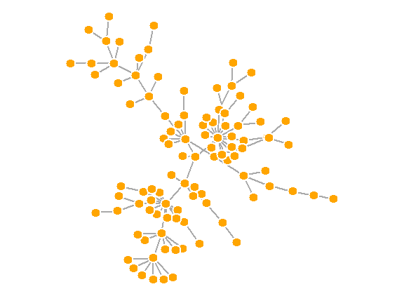

```r
l <- layout_with_kk(net.bg)
plot(net.bg, layout=l)
```

Graphopt is a nice force-directed layout implemented in `igraph` that uses layering to help with visualizations of large networks.

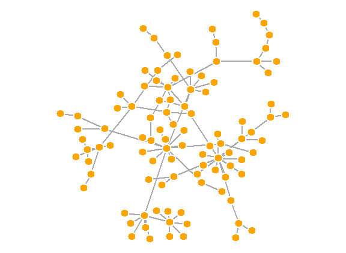

```r
l <- layout_with_graphopt(net.bg)
plot(net.bg, layout=l)
```

The available `graphopt` parameters can be used to change the mass and electric charge of nodes, as well as the optimal spring length and the spring constant for edges. The parameter names are `charge` (defaults to 0.001), `mass` (defaults to 30), `spring.length` (defaults to 0), and `spring.constant` (defaults to 1). Tweaking those can lead to considerably different graph layouts.

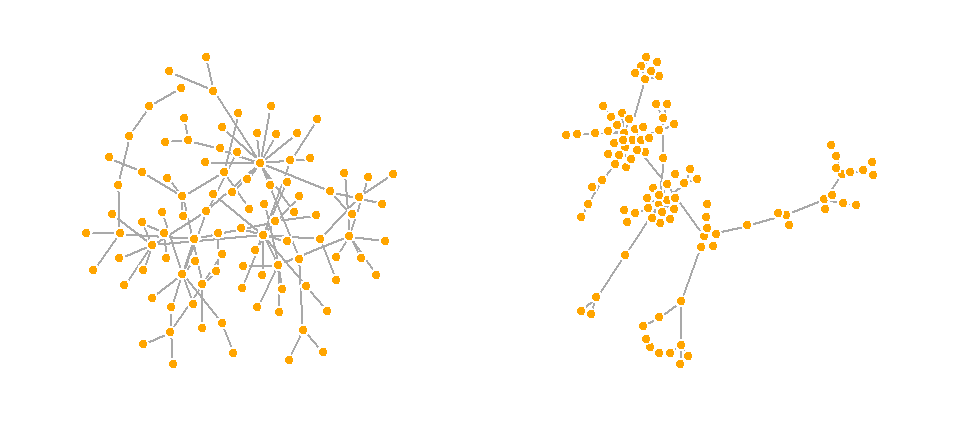

```r
# The charge parameter below changes node repulsion:
l1 <- layout_with_graphopt(net.bg, charge=0.02)
l2 <- layout_with_graphopt(net.bg, charge=0.00000001)

par(mfrow=c(1,2), mar=c(1,1,1,1))
plot(net.bg, layout=l1)
plot(net.bg, layout=l2)
```

```r
dev.off()
```

The LGL algorithm is meant for large, connected graphs. Here you can also specify a root: a node that will be placed in the middle of the layout.

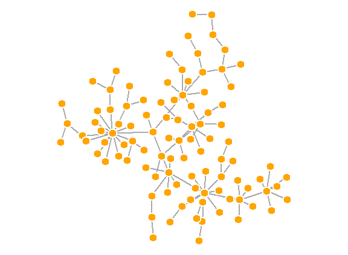

```r
plot(net.bg, layout=layout_with_lgl)
```

The MDS (multidimensional scaling) algorithm tries to place nodes based on some measure of similarity or distance between them. More similar nodes are plotted closer to each other. By default, the measure used is based on the shortest paths between nodes in the network. We can change that by using our own distance matrix (however defined) with the parameter `dist`. MDS layouts are nice because positions and distances have a clear interpretation. The problem with them is visual clarity: nodes often overlap, or are placed on top of each other.

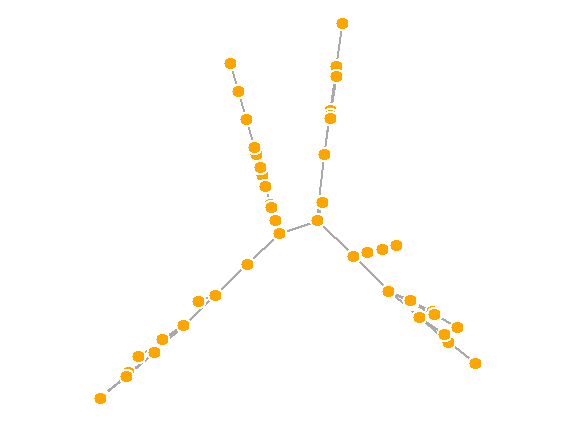

```r
plot(net.bg, layout=layout_with_mds)
```

Let’s take a look at all available layouts in igraph:

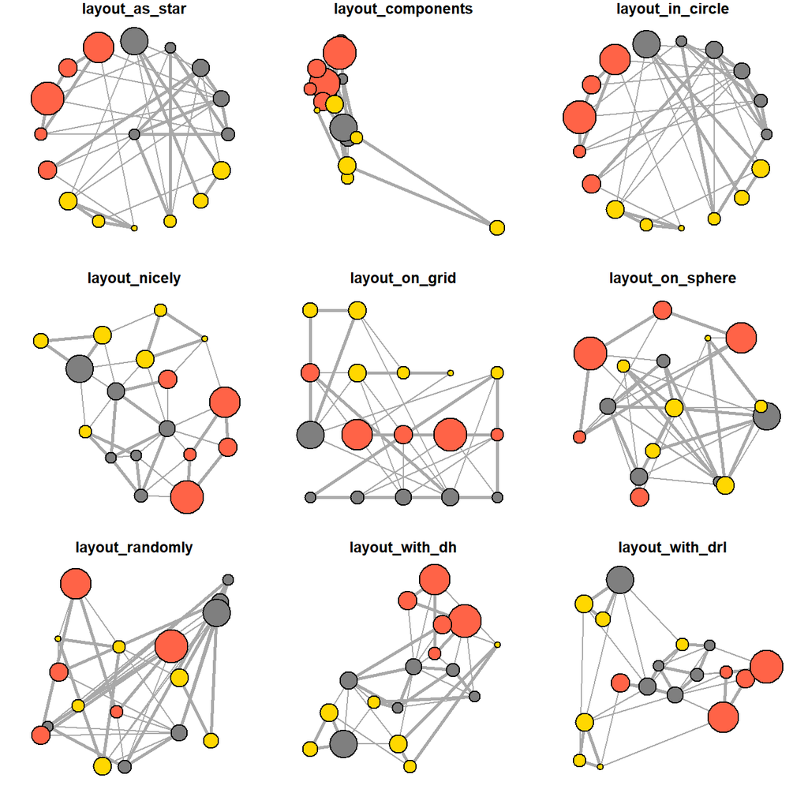

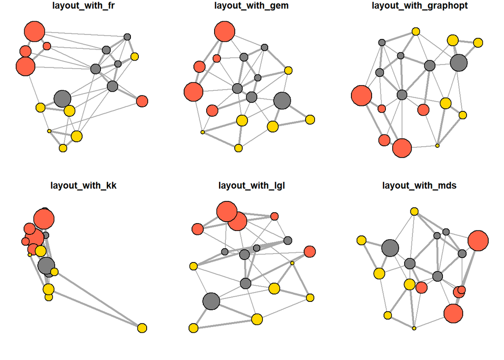

```r
layouts <- grep("^layout_", ls("package:igraph"), value=TRUE)[-1]
# Remove layouts that do not apply to our graph.
layouts <- layouts[!grepl("bipartite|merge|norm|sugiyama|tree", layouts)]

par(mfrow=c(3,3), mar=c(1,1,1,1))
for (layout in layouts) {
  print(layout)
  l <- do.call(layout, list(net))
  plot(net, edge.arrow.mode=0, layout=l, main=layout) }
```

## 4.3 *Highlighting aspects of the network*

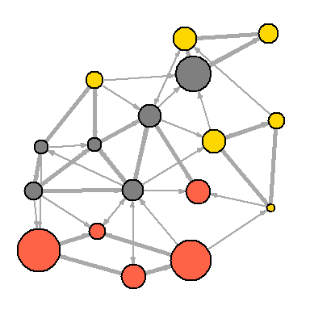

Notice that our network plot is still not too helpful. We can identify the type and size of nodes, but cannot see much about the structure since the links we’re examining are so dense. One way to approach this is to see if we can sparsify the network, keeping only the most important ties and discarding the rest.

```r
hist(links$weight)
mean(links$weight)
sd(links$weight)
```

[output not shown]

There are more sophisticated ways to extract the key edges, but for the purposes of this exercise we’ll only keep ones that have weight higher than the mean for the network. In igraph, we can delete edges using `delete_edges(net, edges)`:

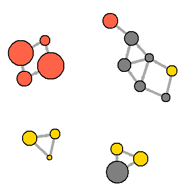

```r
cut.off <- mean(links$weight)
net.sp <- delete_edges(net, E(net)[weight<cut.off])
plot(net.sp, layout=layout_with_kk)
```

We can also try to make the network map more useful by showing the communities within it:

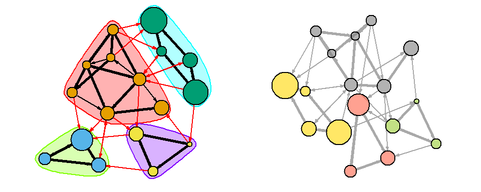

```r
par(mfrow=c(1,2))

# Community detection (by optimizing modularity over partitions):
clp <- cluster_optimal(net)
class(clp)

# Community detection returns an object of class "communities"
# which igraph knows how to plot:
plot(clp, net)

# We can also plot the communities without relying on their built-in plot:
V(net)$community <- clp$membership
colrs <- adjustcolor( c("gray50", "tomato", "gold", "yellowgreen"), alpha=.6)
plot(net, vertex.color=colrs[V(net)$community])
```

```r
dev.off()
```

## 4.4 *Highlighting specific nodes or links*

Sometimes we want to focus the visualization on a particular node or a group of nodes. In our example media network, we can examine the spread of information from focal actors. For instance, let’s represent distance from the NYT.

The `distances` function returns a matrix of shortest paths from nodes listed in the `v` parameter to ones included in the `to` parameter.

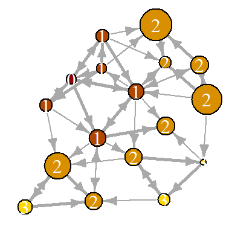

```r
dist.from.NYT <- distances(net, v=V(net)[media=="NY Times"],
                           to=V(net), weights=NA)

# Set colors to plot the distances:
oranges <- colorRampPalette(c("dark red", "gold"))
col <- oranges(max(dist.from.NYT)+1)
col <- col[dist.from.NYT+1]

plot(net, vertex.color=col, vertex.label=dist.from.NYT, edge.arrow.size=.6,
     vertex.label.color="white")
```

We can also highlight a path in the network:

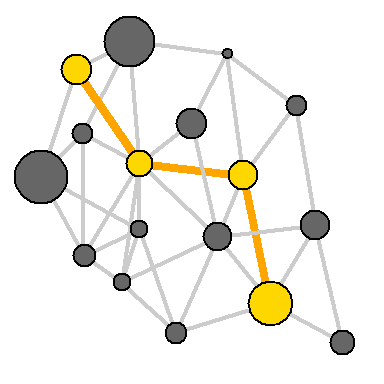

```r
news.path <- shortest_paths(net,
                            from = V(net)[media=="MSNBC"],
                             to  = V(net)[media=="New York Post"],
                             output = "both") # both path nodes and edges

# Generate edge color variable to plot the path:
ecol <- rep("gray80", ecount(net))
ecol[unlist(news.path$epath)] <- "orange"
# Generate edge width variable to plot the path:
ew <- rep(2, ecount(net))
ew[unlist(news.path$epath)] <- 4
# Generate node color variable to plot the path:
vcol <- rep("gray40", vcount(net))
vcol[unlist(news.path$vpath)] <- "gold"

plot(net, vertex.color=vcol, edge.color=ecol,
     edge.width=ew, edge.arrow.mode=0)
```

We can highlight the edges going into or out of a vertex, for instance the WSJ. For a single node, use `incident()`, for multiple nodes use `incident_edges()`

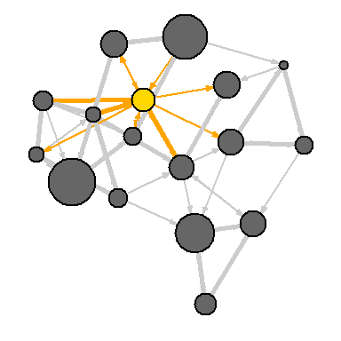

```r
inc.edges <- incident(net,  V(net)[media=="Wall Street Journal"], mode="all")

# Set colors to plot the selected edges.
ecol <- rep("gray80", ecount(net))
ecol[inc.edges] <- "orange"
vcol <- rep("grey40", vcount(net))
vcol[V(net)$media=="Wall Street Journal"] <- "gold"
plot(net, vertex.color=vcol, edge.color=ecol)
```

We can also point to the immediate neighbors of a vertex, say WSJ. The `neighbors` function finds all nodes one step out from the focal actor.To find the neighbors for multiple nodes, use `adjacent_vertices()` instead of `neighbors()`. To find node neighborhoods going more than one step out, use function `ego()` with parameter *`order`* set to the number of steps out to go from the focal node(s).

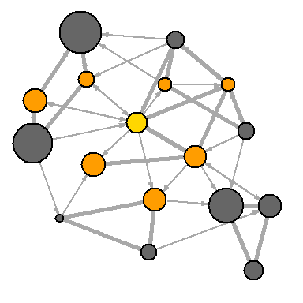

```r
neigh.nodes <- neighbors(net, V(net)[media=="Wall Street Journal"], mode="out")

# Set colors to plot the neighbors:
vcol[neigh.nodes] <- "#ff9d00"
plot(net, vertex.color=vcol)
```

A way to draw attention to a group of nodes (we saw this before with communities) is to “mark” them:

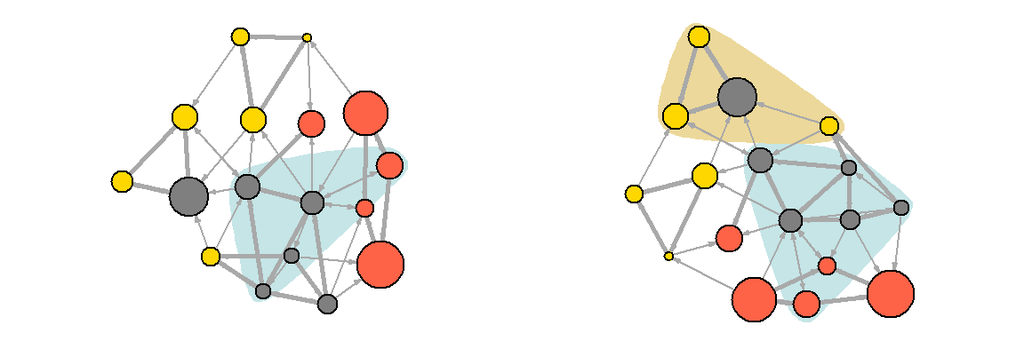

```r
par(mfrow=c(1,2))
plot(net, mark.groups=c(1,4,5,8), mark.col="#C5E5E7", mark.border=NA)

# Mark multiple groups:
plot(net, mark.groups=list(c(1,4,5,8), c(15:17)),
          mark.col=c("#C5E5E7","#ECD89A"), mark.border=NA)
```

```r
dev.off()
```

## 4.5 *Interactive plotting with tkplot*

R and igraph allow for interactive plotting of networks. This might be a useful option for you if you want to tweak slightly the layout of a small graph. After adjusting the layout manually, you can get the coordinates of the nodes and use them for other plots.

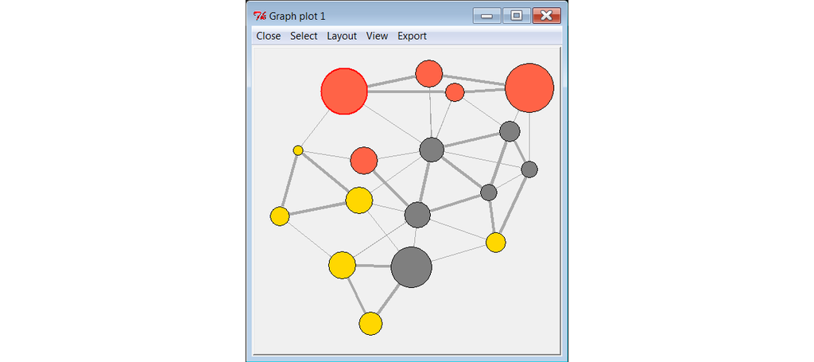

```r
tkid <- tkplot(net) #tkid is the id of the tkplot that will open
l <- tkplot.getcoords(tkid) # grab the coordinates from tkplot
plot(net, layout=l)
```

## 4.6 *Plotting two-mode networks*

As you might remember, our second media example is a two-mode network examining links between news sources and their consumers.

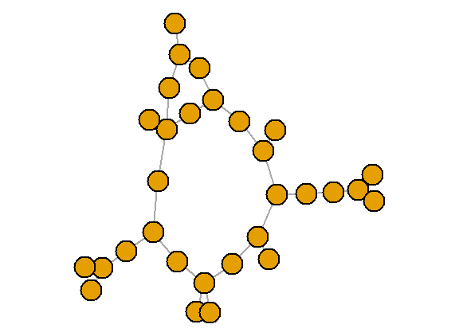

```r
head(nodes2)
head(links2)

net2
plot(net2, vertex.label=NA)
```

As with one-mode networks, we can modify the network object to include the visual properties that will be used by default when plotting the network. Notice that this time we will also change the shape of the nodes - media outlets will be squares, and their users will be circles.

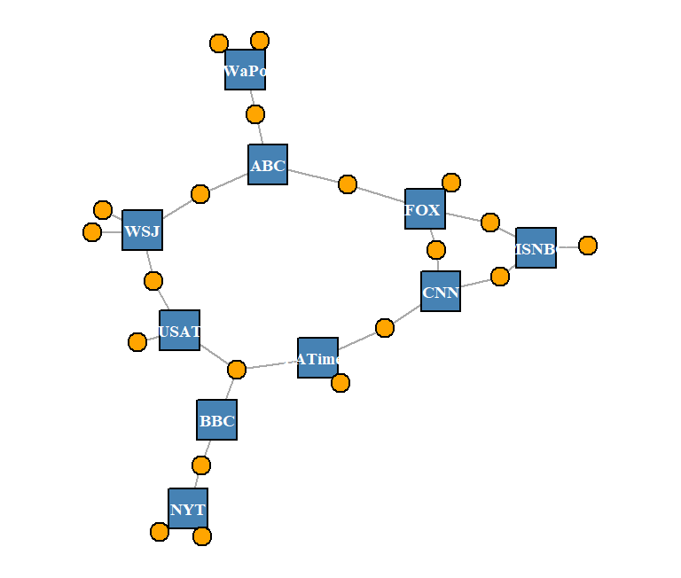

```r
# Media outlets are blue squares, audience nodes are orange circles:
V(net2)$color <- c("steel blue", "orange")[V(net2)$type+1]
V(net2)$shape <- c("square", "circle")[V(net2)$type+1]

# Media outlets will have name labels, audience members will not:
V(net2)$label <- ""
V(net2)$label[V(net2)$type==F] <- nodes2$media[V(net2)$type==F]
V(net2)$label.cex=.6
V(net2)$label.font=2

plot(net2, vertex.label.color="white", vertex.size=(2-V(net2)$type)*8)
```

In `igraph`, there is also a special layout for bipartite networks (though it doesn’t always work great, and you might be better off generating your own two-mode layout).

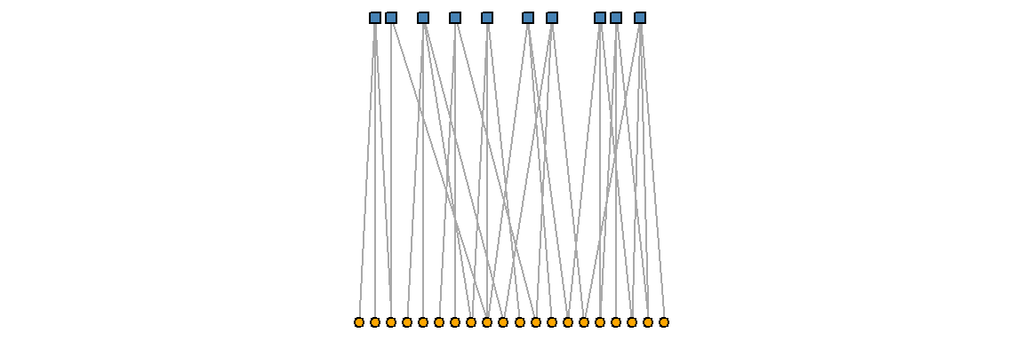

```r
plot(net2, vertex.label=NA, vertex.size=7, layout=layout.bipartite)
```

Using text as nodes may be helpful at times:

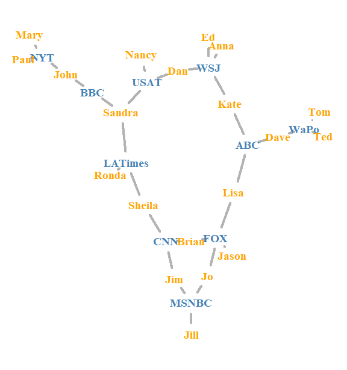

```r
plot(net2, vertex.shape="none", vertex.label=nodes2$media,
     vertex.label.color=V(net2)$color, vertex.label.font=2,
     vertex.label.cex=.6, edge.color="gray70",  edge.width=2)
```

In this example, we will also experiment with the use of images as nodes. In order to do this, you will need the `png` package (if missing, install with `install.packages('png')`

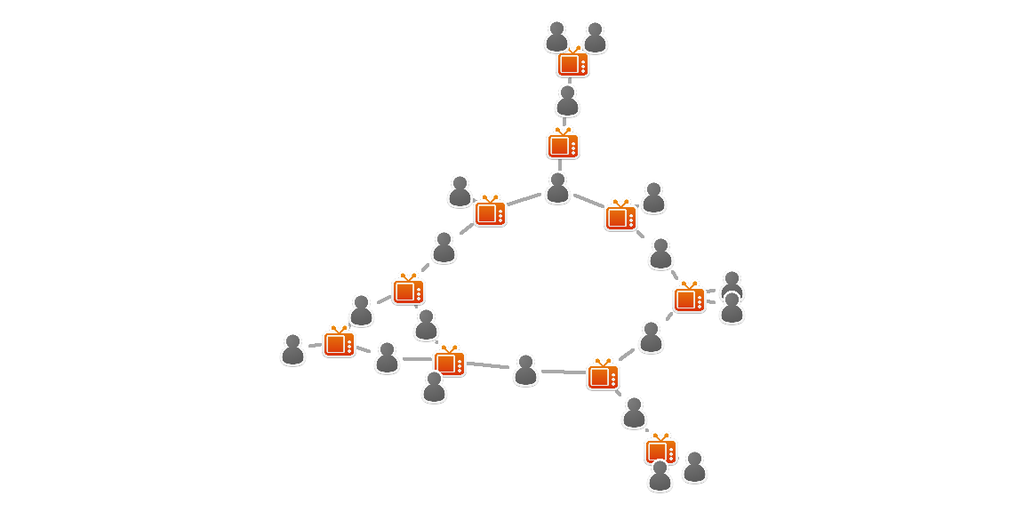

```r
# install.packages('png')
library('png')

img.1 <- readPNG("./images/news.png")
img.2 <- readPNG("./images/user.png")

V(net2)$raster <- list(img.1, img.2)[V(net2)$type+1]

plot(net2, vertex.shape="raster", vertex.label=NA,
     vertex.size=16, vertex.size2=16, edge.width=2)
```

By the way, we can also add any image we want to a plot. For example, many network graphs can be largely improved by a photo of a puppy in a teacup.

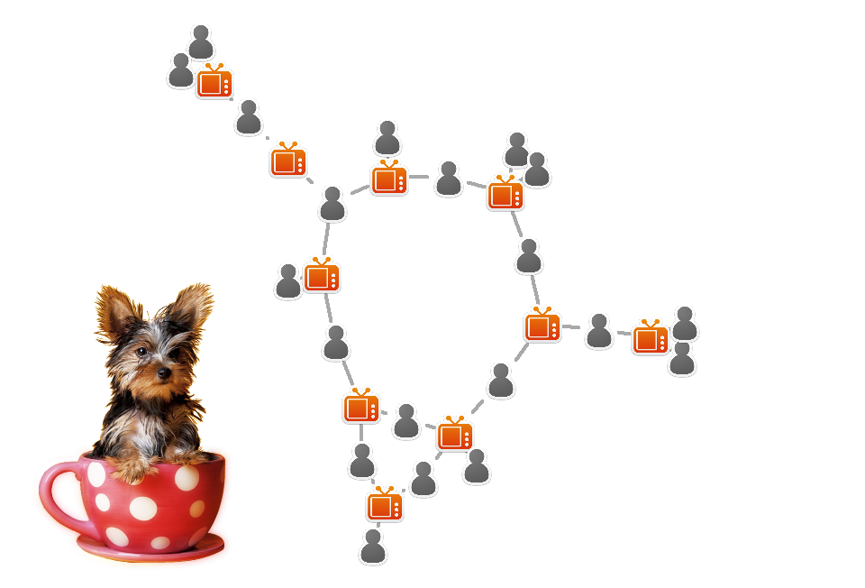

```r
plot(net2, vertex.shape="raster", vertex.label=NA,
     vertex.size=16, vertex.size2=16, edge.width=2)

img.3 <- readPNG("./images/puppy.png")
rasterImage(img.3,  xleft=-1.6, xright=-0.6, ybottom=-1.1, ytop=0.1)
```

```r
# The numbers after the image are its coordinates
# The limits of your plotting area are given in par()$usr
```

We can also generate and plot bipartite projections for the two-mode network: co-memberships are easy to calculate by multiplying the network matrix by its transposed matrix, or using igraph’s `bipartite.projection()` function.

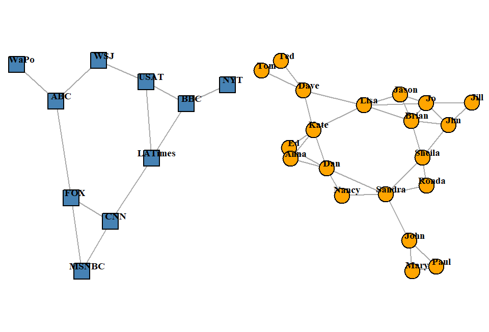

```r
par(mfrow=c(1,2))

net2.bp <- bipartite.projection(net2)

plot(net2.bp$proj1, vertex.label.color="black", vertex.label.dist=1,
     vertex.label=nodes2$media[!is.na(nodes2$media.type)])

plot(net2.bp$proj2, vertex.label.color="black", vertex.label.dist=1,
     vertex.label=nodes2$media[ is.na(nodes2$media.type)])
```

```r
dev.off()
```

## 4.7 *Plotting multiplex networks*

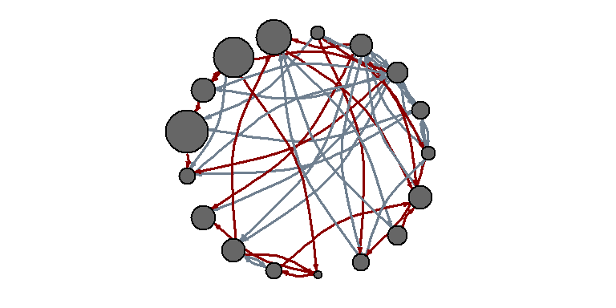

```r
E(net)$width <- 1.5
plot(net, edge.color=c("dark red", "slategrey")[(E(net)$type=="hyperlink")+1],
      vertex.color="gray40", layout=layout_in_circle, edge.curved=.3)
```

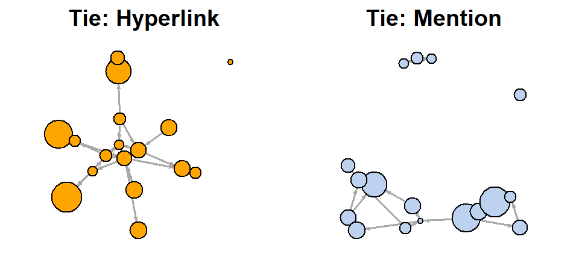

```r
net.m <- net - E(net)[E(net)$type=="hyperlink"] # another way to delete edges:
net.h <- net - E(net)[E(net)$type=="mention"]   # using the minus operator

# Plot the two links separately:
par(mfrow=c(1,2))
plot(net.h, vertex.color="orange", layout=layout_with_fr, main="Tie: Hyperlink")
plot(net.m, vertex.color="lightsteelblue2", layout=layout_with_fr, main="Tie: Mention")
```

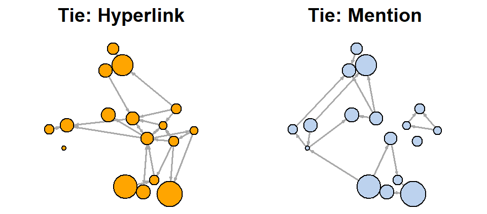

```r
# Make sure the nodes stay in place in both plots:
l <- layout_with_fr(net)
plot(net.h, vertex.color="orange", layout=l, main="Tie: Hyperlink")
plot(net.m, vertex.color="lightsteelblue2", layout=l, main="Tie: Mention")
```

```r
dev.off()
```

In our example network, it so happens that we do not have node dyads connected by multiple types of connections. That is to say, we never have both a ‘hyperlink’ and a ‘mention’ tie between the same two news outlets. However, this could easily happen in a multiplex network.

One challenge in visualizing multigraphs is that multiple edges between the same two nodes may get plotted on top of each other in a way that makes impossible to see them clearly. For example, let us generate a very simple multiplex network with two nodes and three ties between them:

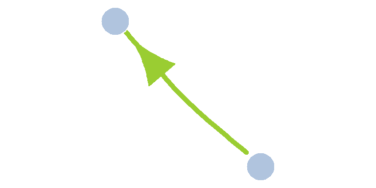

```r
multigtr <- graph( edges=c(1,2, 1,2, 1,2), n=2 )
l <- layout_with_kk(multigtr)

# Let's just plot the graph:
plot(multigtr, vertex.color="lightsteelblue", vertex.frame.color="white",
     vertex.size=40, vertex.shape="circle", vertex.label=NA,
     edge.color=c("gold", "tomato", "yellowgreen"), edge.width=5,
     edge.arrow.size=3, edge.curved=0.1, layout=l)
```

Because all edges in the graph have the same curvature, they are drawn over each other so that we only see one of them. What we can do is assign each edge a different curvature. One useful function in `igraph` called `curve_multiple` can help us here. For a graph `G`, `curve.multiple(G)` will generate a curvature for each edge that maximizes visibility.

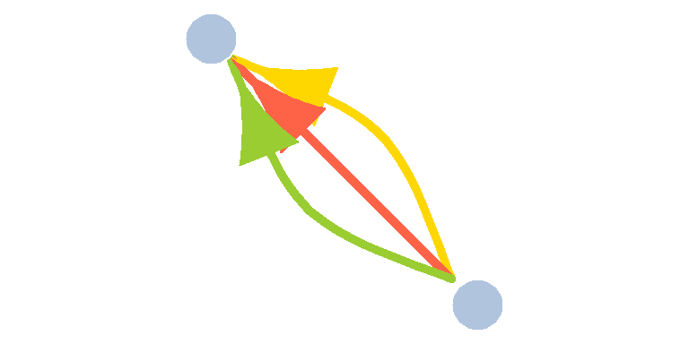

```r
plot(multigtr, vertex.color="lightsteelblue", vertex.frame.color="white",
     vertex.size=40, vertex.shape="circle", vertex.label=NA,
     edge.color=c("gold", "tomato", "yellowgreen"), edge.width=5,
     edge.arrow.size=3, edge.curved=curve_multiple(multigtr), layout=l)
```

It is a good practice to detach packages when we stop needing them. Try to remember that especially with `igraph` and the `statnet` family packages, as bad things tend to happen if you have them loaded together.

```r
detach('package:igraph')
```

# 5 Beyond *igraph*: *Statnet*, *ggraph*, and simple charts

The `igraph` package is only one of many available network visualization options in *R*. This section provides a few quick examples illustrating other available approaches to static network visualization.

## 5.1 *A network package example (for Statnet users)*

Plotting with the `network` package is very similar to that with `igraph` - although the notation is slightly different (a whole new set of parameter names!). This package also uses less default controls obtained by modifying the network object, and more explicit parameters in the plotting function.

Here is a quick example using the (by now familiar) media network. We will begin by converting the data into the `network` format used by the Statnet family of packages (including `network`, `sna`, `ergm`, `stergm`, and others).

As in `igraph`, we can generate a ‘network’ object from an edge list, an adjacency matrix, or an incidence matrix. You can get the specifics with `?edgeset.constructors`. Here we will use the edge list and the node attribute data frames to create the network object. One specific thing to pay attention to here is the `ignore.eval` parameter. It is set to `TRUE` by default, and that setting causes the network object to disregard edge weights.

```r
library('network')

net3 <- network(links,  vertex.attr=nodes, matrix.type="edgelist",
                loops=T, multiple=F, ignore.eval = F)
```

Here again we can easily access the edges, vertices, and the network matrix:

```r
net3[,]
net3 %n% "net.name" <- "Media Network" #  network attribute
net3 %v% "media"    # Node attribute
net3 %e% "type"     # Edge attribute
```

Let’s plot our media network once again:

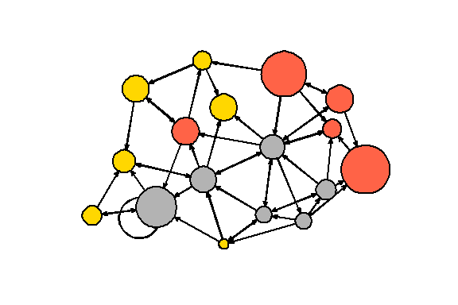

```r
net3 %v% "col" <- c("gray70", "tomato", "gold")[net3 %v% "media.type"]
plot(net3, vertex.cex=(net3 %v% "audience.size")/7, vertex.col="col")
```

Note that - as in igraph - the plot returns the node position coordinates. You can use them in other plots using the `coord` parameter.

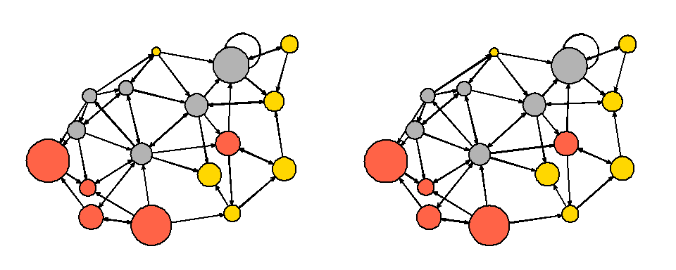

```r
l <- plot(net3, vertex.cex=(net3 %v% "audience.size")/7, vertex.col="col")
plot(net3, vertex.cex=(net3 %v% "audience.size")/7, vertex.col="col", coord=l)
```

```r
detach('package:network')
```

The network package also offers the option to edit a plot interactively, by setting the parameter `interactive=T`:

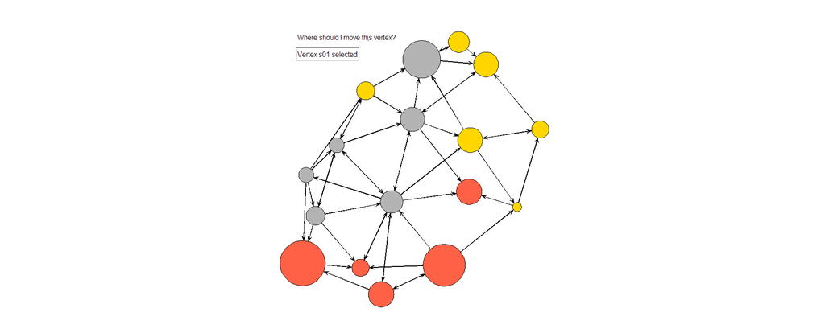

Interactive

```r
plot(net3, vertex.cex=(net3 %v% "audience.size")/7, vertex.col="col", interactive=T)
```

For a full list of parameters that you can use in the `network` package, check out `?plot.network`.

## 5.2 *A ggraph package example (for ggplot2 users)*

The `ggplot2` package and its extensions are known for offering the most meaningfully structured and advanced way to visualize data in R. In `ggplot2`, you can select from a variety of visual building blocks and add them to your graphics one by one, a layer at a time.

The `ggraph` package takes this principle and extends it to network data. In this section, we’ll only cover the basics without providing a detailed overview of the grammar of graphics approach. For a deeper look, it would be best to get familiar with `ggplot2` first, then learn the specifics of `ggraph`.

One good news is that we can use our `igraph` objects directly with the `ggraph` package. The following code gets the data and adds separate layers for nodes and links.

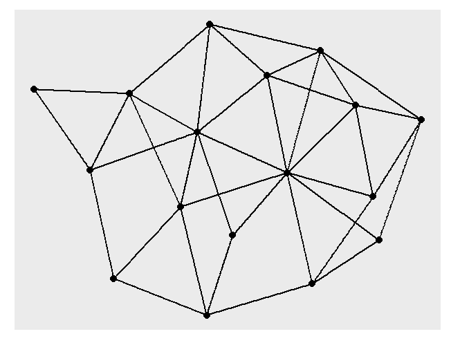

```r
library(ggraph)
library(igraph)

ggraph(net) +
  geom_edge_link() +   # add edges to the plot
  geom_node_point()    # add nodes to the plot
```

You will also recognize here some network layouts familiar from `igraph` plotting: ‘star’, ‘circle’, ‘grid’, ‘sphere’, ‘kk’, ‘fr’, ‘mds’, ‘lgl’, etc.

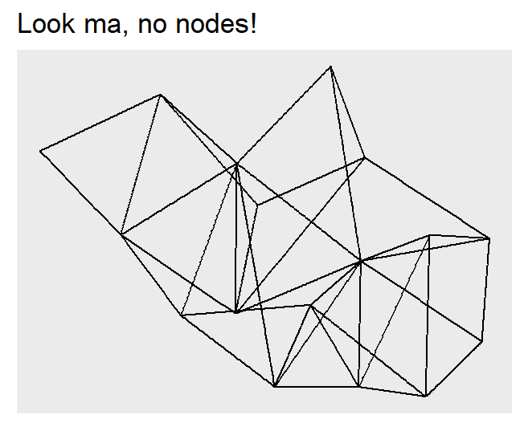

```r
ggraph(net, layout="lgl") +
  geom_edge_link() +
  ggtitle("Look ma, no nodes!")  # add title to the plot
```

Here we can use `geom_edge_link()` for straight edges, `geom_edge_arc()` for curved ones, and `geom_edge_fan()` when we want to make sure any overlapping multiplex edges will be fanned out.

As in other packages, we can set visual properties for the network plot by using key function parameters. For instance, nodes have `color`, `fill`, `shape`, `size`, and `stroke`. Edges have `color`, `width`, and `linetype`. Here too the `alpha` parameter controls transparency.

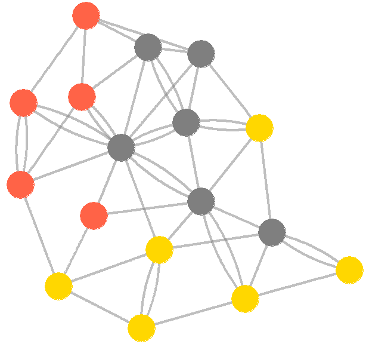

```r
ggraph(net, layout="lgl") +
  geom_edge_fan(color="gray50", width=0.8, alpha=0.5) +
  geom_node_point(color=V(net)$color, size=8) +
  theme_void()
```

As in `ggplot2`, we can add different themes to the plot. For a cleaner look, you can use a minimal or empty theme with `theme_minimal()` or `theme_void()`.

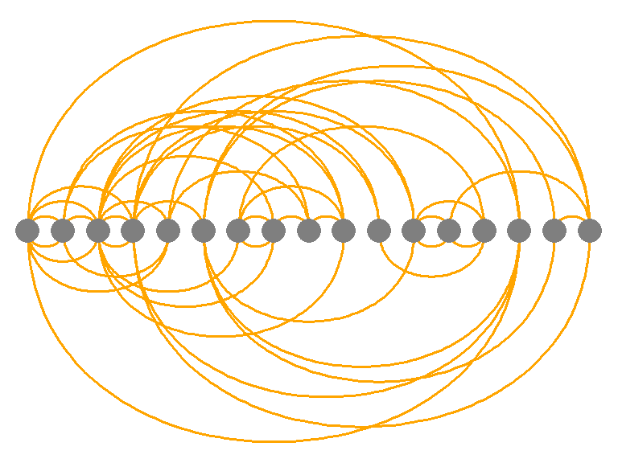

```r
ggraph(net, layout = 'linear') +
    geom_edge_arc(color = "orange", width=0.7) +
    geom_node_point(size=5, color="gray50") +
    theme_void()
```

The `ggraph` package also uses the traditional `ggplot2` way of mapping aesthetics: that is to say, of specifying which elements of the data should correspond to different visual properties of the graphic. This is done using the `aes()` function that matches visual parameters with attribute names from the data. In the code below, the edge attribute `type` and node attribute `audience.size` are taken from our data as they are included in the `igraph` object.

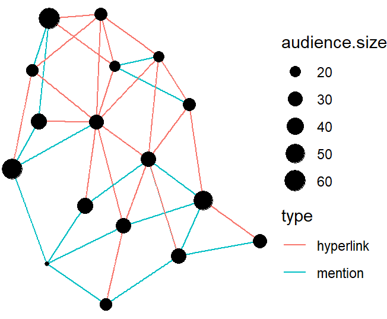

```r
ggraph(net, layout="lgl") +
  geom_edge_link(aes(color = type)) +           # colors by edge type
  geom_node_point(aes(size = audience.size)) +  # size by audience size
  theme_void()
```

One great thing about `ggplot2` and `ggraph` you can see above is that they automatically generate a legend which makes plots easier to interpret.

We can add a layer with node labels using `geom_node_text()` or `geom_node_label()` which correspond to similar functions in `ggplot2`.

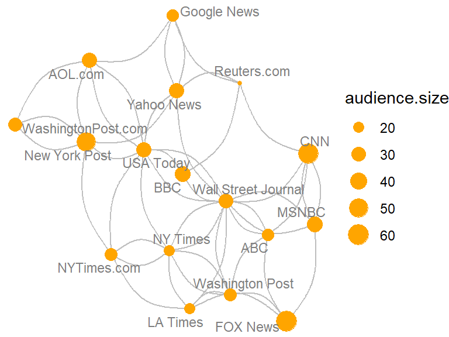

```r
ggraph(net,  layout = 'lgl') +
  geom_edge_arc(color="gray", strength=0.3) +
  geom_node_point(color="orange", aes(size = audience.size)) +
  geom_node_text(aes(label = media), size=3, color="gray50", repel=T) +
  theme_void()
```

```r
detach("package:ggraph")
```

While those are not discussed here, note that `ggraph` offers a number of other interesting ways to represent networks, including dendrograms, treemaps, hive plots, and circle plots.

## 5.3 *Other ways to represent a network*

At this point, it might be useful to provide a quick reminder that there are many ways to represent a network not limited to a hairball plot.

For example, here is a quick heatmap of the network matrix.

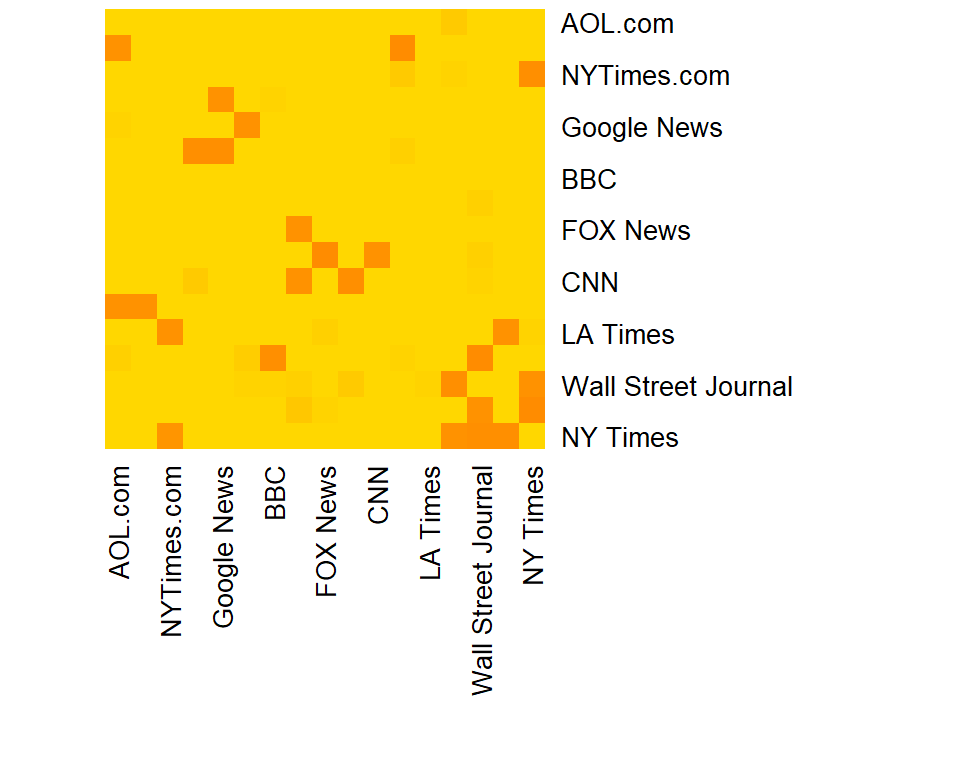

```r
netm <- get.adjacency(net, attr="weight", sparse=F)
colnames(netm) <- V(net)$media
rownames(netm) <- V(net)$media

palf <- colorRampPalette(c("gold", "dark orange"))
heatmap(netm[,17:1], Rowv = NA, Colv = NA, col = palf(100),
        scale="none", margins=c(10,10) )
```

Depending on what properties of the network or its nodes and edges are most important to you, simple graphs can often be more informative than network maps.

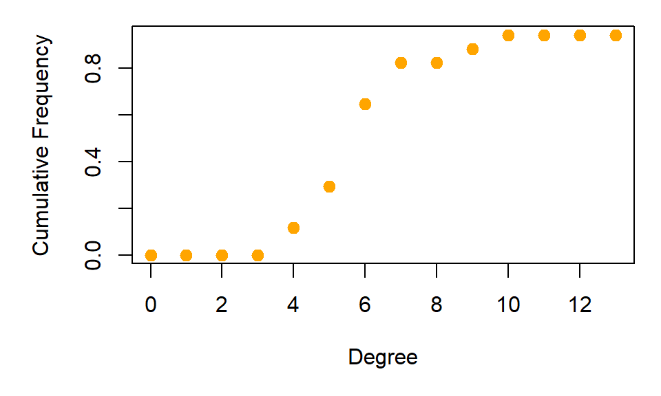

```r
# Plot the egree distribution for our network:
deg.dist <- degree_distribution(net, cumulative=T, mode="all")
plot( x=0:max(degree(net)), y=1-deg.dist, pch=19, cex=1.2, col="orange",
      xlab="Degree", ylab="Cumulative Frequency")
```

# 6 Interactive network visualizations

## 6.1 *Simple plot animations in R*

If you have already installed “ndtv”, you should also have a package used by it called “animation”. If not, now is a good time to install it with `install.packages('animation')`. Note that this package provides a simple technique to create various (not necessarily network-related) animations in R. It works by generating multiple plots and combining them in an animated GIF.

The catch here is that in order for this to work, you need not only the R package, but also an additional software called [ImageMagick (imagemagick.org)](http://imagemagick.org). You probably don’t want to install that during the workshop, but you can try it at home.

The good news is that once you figure this out, you can turn any series of `R` plots (network or not!) into an animated GIF.

```r
library('animation')
library('igraph')

ani.options("convert") # Check that the package knows where to find ImageMagick
# If it doesn't know where to find it, give it the correct path for your system.
ani.options(convert="C:/Program Files/ImageMagick-6.8.8-Q16/convert.exe")
```

We will now generate 4 network plots (the same way we did before), only this time we’ll do it within the `saveGIF` command. The animation interval is set with `interval`, and the `movie.name` parameter controls name of the gif.

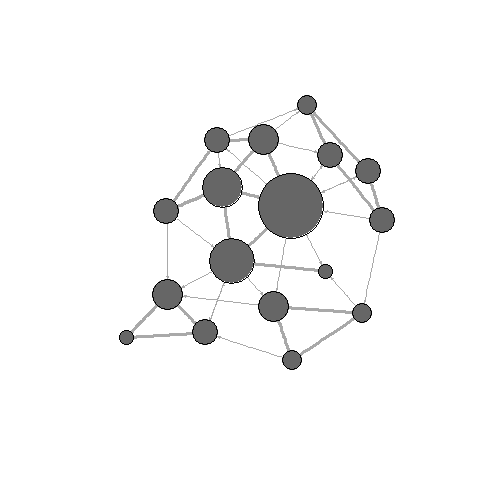

```r
l <- layout_with_lgl(net)

saveGIF( {  col <- rep("grey40", vcount(net))
            plot(net, vertex.color=col, layout=l)

            step.1 <- V(net)[media=="Wall Street Journal"]
            col[step.1] <- "#ff5100"
            plot(net, vertex.color=col, layout=l)

            step.2 <- unlist(neighborhood(net, 1, step.1, mode="out"))
            col[setdiff(step.2, step.1)] <- "#ff9d00"
            plot(net, vertex.color=col, layout=l)

            step.3 <- unlist(neighborhood(net, 2, step.1, mode="out"))
            col[setdiff(step.3, step.2)] <- "#FFDD1F"
            plot(net, vertex.color=col, layout=l)  },
          interval = .8, movie.name="network_animation.gif" )

 detach('package:igraph')
 detach('package:animation')
```

## 6.2 *Interactive JS visualization with visNetwork*

These days it is fairly easy to export R plots to HTML/JavaScript output. There are a number of packages like `rcharts` and `htmlwidgets` that can help you create interactive web charts right from R. One thing to keep in mind though is that the network visualizations created that way are most helpful as a starting point for further work. If you know a little bit of javascript, you can use them as a first step and tweak the results to get closer to what you want.

Here we will take a quick look at [`visNetwork`](http://datastorm-open.github.io/visNetwork/) which generates interactive network visualizations using the [`vis.js`](http://visjs.org) javascript library. You can install the package with `install.packages('visNetwork')`.

We can visualize our media network right away: `visNetwork()` will accept our node and link data frames. As usual, the node data frame needs to have an `id` column, and the link data needs to have `from` and `to` columns denoting the start and end of each tie.

```r
library('visNetwork')
visNetwork(nodes, links, width="100%", height="400px")
```

[interactive chart not shown]

If we want to set specific height and width for the interactive plot, we can do that with the `height` and `width` parameters. As is often the case in `R`, the title of the plot is set with the `main` parameter. The subtitle and footer can be set with `submain` and `footer` respectively.

```r
visNetwork(nodes, links, width="100%", height="400px", background="#eeefff",
           main="Network", submain="And what a great network it is!",
           footer= "Hyperlinks and mentions among media sources")
```

[interactive chart not shown]

Like the `igraph` package, `visNetwork` allows us to set graphic properties as node or edge attributes. We can simply add them as columns in our data before we call the `visNetwork()` function. Check out the available options with:

```r
?visNodes
?visEdges
```

In the following code, we are changing some of the visual parameters for nodes. We start with the node shape (the available options for it include `ellipse`, `circle`, `database`, `box`, `text`, `image`, `circularImage`, `diamond`, `dot`, `star`, `triangle`, `triangleDown`, `square`, and `icon`). We are also going to change the color of several node elements. In this package, `background` controls the node color, `border` changes the frame color; `highlight` sets the color on mouse click, and `hover` sets the color on mouseover.

```r
# We'll start by adding new node and edge attributes to our dataframes.
vis.nodes <- nodes
vis.links <- links

vis.nodes$shape  <- "dot"
vis.nodes$shadow <- TRUE # Nodes will drop shadow
vis.nodes$title  <- vis.nodes$media # Text on click
vis.nodes$label  <- vis.nodes$type.label # Node label
vis.nodes$size   <- vis.nodes$audience.size # Node size
vis.nodes$borderWidth <- 2 # Node border width

vis.nodes$color.background <- c("slategrey", "tomato", "gold")[nodes$media.type]
vis.nodes$color.border <- "black"
vis.nodes$color.highlight.background <- "orange"
vis.nodes$color.highlight.border <- "darkred"

visNetwork(vis.nodes, vis.links)
```

[interactive chart not shown]

Next we will change some of the visual properties of the edges.

```r
vis.links$width <- 1+links$weight/8 # line width
vis.links$color <- "gray"    # line color
vis.links$arrows <- "middle" # arrows: 'from', 'to', or 'middle'
vis.links$smooth <- FALSE    # should the edges be curved?
vis.links$shadow <- FALSE    # edge shadow

visnet <- visNetwork(vis.nodes, vis.links)
visnet
```

[interactive chart not shown]

We can also set the visualization options directly with `visNodes()` and `visEdges()`.

```r
visnet2 <- visNetwork(nodes, links)
visnet2 <- visNodes(visnet2, shape = "square", shadow = TRUE,
            color=list(background="gray", highlight="orange", border="black"))
visnet2 <- visEdges(visnet2, color=list(color="black", highlight = "orange"),
                    smooth = FALSE, width=2, dashes= TRUE, arrows = 'middle' )
visnet2
```

[interactive chart not shown]

`visNetwork` offers a number of other options in the `visOptions()` function. For instance, we can highlight all neighbors of the selected node (`highlightNearest`), or add a drop-down menu to select subset of nodes (`selectedBy`). The subsets are based on a column from our data - here we use the type label.

```r
visOptions(visnet, highlightNearest = TRUE, selectedBy = "type.label")
```

[interactive chart not shown]

`visNetwork` can also work with predefined groups of nodes. The visual characteristics for nodes belonging in each group can be set with `visGroups()`. We can add an automatically generated group legend with `visLegend()`.

```r
nodes$group <- nodes$type.label
visnet3 <- visNetwork(nodes, links)
visnet3 <- visGroups(visnet3, groupname = "Newspaper", shape = "square",
                     color = list(background = "gray", border="black"))
visnet3 <- visGroups(visnet3, groupname = "TV", shape = "dot",
                     color = list(background = "tomato", border="black"))
visnet3 <- visGroups(visnet3, groupname = "Online", shape = "diamond",
                     color = list(background = "orange", border="black"))
visLegend(visnet3, main="Legend", position="right", ncol=1)
```

[interactive chart not shown]

For more information, you can also check out:

```r
?visOptions # available options
?visLayout  # available layouts
?visGroups  # using node groups
?visLegend  # adding a legend

# Detach the package since we're done with it.
detach('package:visNetwork')
```

## 6.3 *Interactive JS visualization with threejs*

Another good package exporting networks from R to javascript is [`threejs`](http://bwlewis.github.io/rthreejs/), which generates interactive network visualizations using the [`three.js`](http://threejs.org) javascript library and the [`htmlwidgets`](http://htmlwidgets.org) `R` package. One nice thing about `threejs` is that it can directly read `igraph` objects.

You can install the package with `install.packages('threejs')`. If you get errors or warnings using this library with the latest version of R, try also installing the development version of the `htmlwidgets` package which may have bug fixes that will help:

```r
devtools::install_github('ramnathv/htmlwidgets')
```

The main network plotting function here,`graphjs`, will take an `igraph` object. We could use our initial `net` object with a slight modification: we will delete its graph layout and let `threejs` generate one on its own. We cheated a bit earlier by assigning a function to the layout attribute in the `igraph` object rather than giving it a table of node coordinates. This is fine by `igraph`, but `threejs` will not let us do it.

```r
library(threejs)
library(htmlwidgets)
library(igraph)

net.js <- net
graph_attr(net.js, "layout") <- NULL
```

Note that `RStudio` for Windows may not render the `threejs` graphics properly. We will save the output in an HTML file and open it in a browser. Some of the parameters that we can add include **main** for the plot title; **curvature** for the edge curvature; **bg** for background color; **showLabels** to set labels to visible (`TRUE`) or not (`FALSE`); **attraction** and **repulsion** to set how much nodes attract and repulse each other in the layout; **opacity** for node transparency (range 0 to 1); **stroke** to indicate whether nodes should be framed in a black circle (`TRUE`) or not (`FALSE`), etc.

For the full list of parameters, check out `?graphjs`.

```r
gjs <- graphjs(net.js, main="Network!", bg="gray10", showLabels=F, stroke=F,
               curvature=0.1, attraction=0.9, repulsion=0.8, opacity=0.9)
print(gjs)
saveWidget(gjs, file="Media-Network-gjs.html")
browseURL("Media-Network-gjs.html")
```

[interactive chart not shown]

Once we open the resulting visualization in a browser, we can use the mouse *scrollwheel* to zoom in and out, the *left mouse button* to rotate the network, and the *right mouse button* to pan.  
We can also create simple animations with `threejs` by using lists of layouts, vertex colors, and edge colors that will switch at each step.

```r
gjs.an <- graphjs(net.js, bg="gray10", showLabels=F, stroke=F,
                  layout=list(layout_randomly(net.js, dim=3),
                              layout_with_fr(net.js,  dim=3),
                              layout_with_drl(net.js, dim=3),
                              layout_on_sphere(net.js)),
                  vertex.color=list(V(net.js)$color, "gray", "orange",
                                    V(net.js)$color),
                  main=list("Random Layout", "Fruchterman-Reingold",
                            "DrL layout", "Sphere" ) )
print(gjs.an)
saveWidget(gjs.an, file="Media-Network-gjs-an.html")
browseURL("Media-Network-gjs-an.html")
```

[interactive chart not shown]

## 6.4 *Interactive JS visualization with networkD3*

We will also take a quick look at [`networkD3`](http://christophergandrud.github.io/d3Network/) which - as its name suggests - generates interactive network visualizations using the [`D3`](http://d3js.org) javascript library. If you d not have the `networkD3` library, install it with `install.packages("networkD3")`.

The data that this library needs from is is in the standard edge list form, with a few little twists. In order for things to work, the node IDs have to be numeric, and they also have to start from 0. An easy was to get there is to transform our character IDs to a factor variable, transform that to numeric, and make sure it starts from zero by subtracting 1.

```r
library(networkD3)

links.d3 <- data.frame(from=as.numeric(factor(links$from))-1,
                       to=as.numeric(factor(links$to))-1 )
```

The nodes need to be in the same order as the “source” column in links:

```r
nodes.d3 <- cbind(idn=factor(nodes$media, levels=nodes$media), nodes)
```

Now we can generate the interactive chart. The `Group` parameter in it is used to color the nodes. `Nodesize` is not (as one might think) the size of the node, but the number of the column in the node data that should be used for sizing. The `charge` parameter controls node repulsion (if negative) or attraction (if positive).

```r
forceNetwork(Links = links.d3, Nodes = nodes.d3, Source="from", Target="to",
               NodeID = "idn", Group = "type.label",linkWidth = 1,
               linkColour = "#afafaf", fontSize=12, zoom=T, legend=T,
               Nodesize=6, opacity = 0.8, charge=-300,
               width = 600, height = 400)
```

[interactive chart not shown]

# 7 Dynamic network visualizations with *ndtv-d3*

Here we will create D3 visualizations using the `ndtv` package. You should not need additional software to produce web animations with `ndtv`. If you want to save the animations as video files (see `?saveVideo`), you have to install a video converter called [FFmpeg (http://ffmpg.org)](http://ffmpg.org). To find out how to get the right installation for your OS, check out `?install.ffmpeg`. To use all available layouts, you would also need to have Java installed on your machine.

## 7.1 *Interactive plots of static networks*

We will start from plots of static network portraying a single time point (or an aggregated time period).

```r
install.packages('ndtv', dependencies=T)
```

As `ndtv` is part of the Statnet family, it will accept objects from the `network` package such as the one we created earlier (`net3`).

```r
library('ndtv')
net3
```

Most of the parameters below are self-explanatory at this point (`bg` is the background color of the plot). Two new parameters we haven’t used before are `vertex.tooltip` and `edge.tooltip`. Those contain the information that we can see when moving the mouse cursor over network elements. Note that the tooltip parameters accepts html tags – for example we will use the line break tag `<br>`. The parameter `launchBrowser` instructs R to open the resulting visualization file (`filename`) in the browser.

```r
par(mar=c(0,0,0,0))

render.d3movie(net3, usearrows = F, displaylabels = F, bg="#111111",
       vertex.border="#ffffff", vertex.col =  net3 %v% "col",
       vertex.cex = (net3 %v% "audience.size")/8,
       edge.lwd = (net3 %e% "weight")/3, edge.col = '#55555599',
       vertex.tooltip = paste("<b>Name:</b>", (net3 %v% 'media') , "<br>",
                              "<b>Type:</b>", (net3 %v% 'type.label')),
       edge.tooltip = paste("<b>Edge type:</b>", (net3 %e% 'type'), "<br>",
                            "<b>Edge weight:</b>", (net3 %e% "weight" ) ),
       launchBrowser=F, filename="Media-Network.html" )
```

[interactive chart not shown]

If you are going to embed the plot in a markdown document, use `output.mode='inline'` above.

## 7.2 *Network evolution animations*

Animations are a good way to show the evolution of small to medium size networks over time. At present, `ndtv` is the best R package for that – especially since it now has D3 capabilities and allows easy export for the Web.

In order to work with the network animations in `ndtv`, we need to understand `Statnet`’s dynamic network format, implemented in the `networkDynamic` package. The format can be used to represent longitudinal structures, both discrete (if you have multiple snapshots of your network at different time points) and continuous (if you have timestamps indicating when edges and/or nodes appear and disappear from the network). The examples below will only scratch the surface of temporal networks in Statnet - for a deeper dive, check out [Skye Bender-deMoll](http://skyeome.net/wordpress/)’s [Temporal network tools tutorial](http://statnet.csde.washington.edu/workshops/SUNBELT/current/ndtv/ndtv_workshop.html) and the [networkDynamic package vignette](https://cran.r-project.org/web/packages/networkDynamic/vignettes/networkDynamic.pdf).

Let’s look at one example dataset included in the package, containing simulation data based on a network of business connections among Renaissance Florentine families:

```r
data(short.stergm.sim)
short.stergm.sim
head(as.data.frame(short.stergm.sim))
```

```
##   onset terminus tail head onset.censored
## 1     0        1    3    5          FALSE
## 2    10       20    3    5          FALSE
## 3     0       25    3    6          FALSE
## 4     0        1    3    9          FALSE
## 5     2       25    3    9          FALSE
## 6     0        4    3   11          FALSE
```

```
##   terminus.censored duration edge.id
## 1             FALSE        1       1
## 2             FALSE       10       1
## 3             FALSE       25       2
## 4             FALSE        1       3
## 5             FALSE       23       3
## 6             FALSE        4       4
```

What we see here is a temporal edge list. An edge goes from a node with ID in the `tail` column to a node with ID in the `head` column. Edges exist from time point `onset` to time point `terminus`. As you can see in our example, there may be multiple periods (*activity spells*) where an edge is present. Each of those periods is recorded on a separate row in the data frame above.

The idea of onset and terminus *censoring* refers to start and end points enforced by the beginning and end of network observation rather than by actual tie formation/dissolution.

We can simply plot the network disregarding its time component (combining all nodes and edges that were ever present):

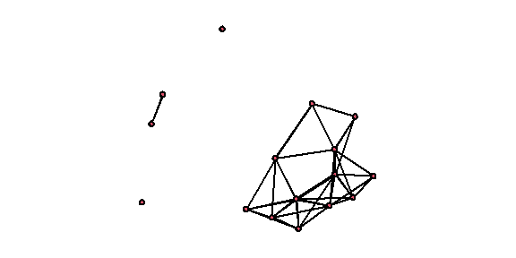

```r
plot(short.stergm.sim)
```

We can also use `network.extract()` to get a network that only contains elements active at a given point, or during a given time interval. For instance, we can plot the network at time 1 (`at=1`):

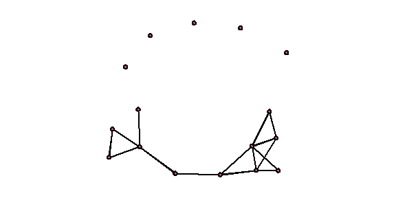

```r
plot( network.extract(short.stergm.sim, at=1) )
```

Plot nodes and edges that were active for the entire period (`rule=all`) from time 1 to time 5:

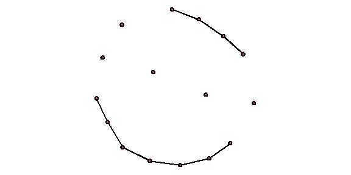

```r
plot( network.extract(short.stergm.sim, onset=1, terminus=5, rule="all") )
```

Plot nodes and edges that were active at any point (`rule=any`) between time 1 and time 10:

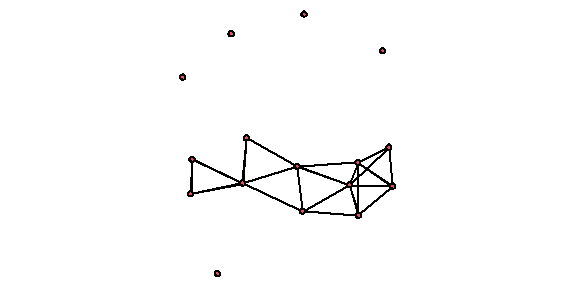

```r
plot( network.extract(short.stergm.sim, onset=1, terminus=10, rule="any") )
```

Let’s make a quick d3 animation from the example network:

```r
render.d3movie(short.stergm.sim,displaylabels=TRUE)
```

[interactive chart not shown]

Next, we will create and animate our own dynamic network. Dynamic network objects can be generated in a number of ways: from a set of networks/matrices representing different time points; from data frames/matrices with node lists and edge lists indicating when each is active, or when they switch state. You can check out `?networkDynamic` for more information.

We are going to add a time component to our media network example. The code below takes a 0-to-50 time interval and sets the nodes in the network as active throughout (time 0 to 50). The edges of the network appear one by one, and each one is active from their first activation until time point 50. We generate this longitudinal network using `networkDynamic` with our node times as `node.spells` and edge times as `edge.spells`.

```r
vs <- data.frame(onset=0, terminus=50, vertex.id=1:17)
es <- data.frame(onset=1:49, terminus=50,
                 head=as.matrix(net3, matrix.type="edgelist")[,1],
                 tail=as.matrix(net3, matrix.type="edgelist")[,2])

net3.dyn <- networkDynamic(base.net=net3, edge.spells=es, vertex.spells=vs)
```

If we try to just plot the `networkDynamic` network, we get a combined network for the entire time period under observation – or as it happens, our original media example.

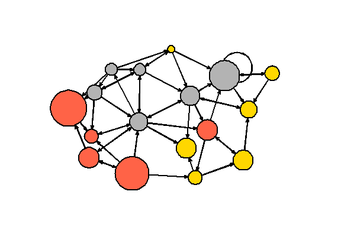

```r
plot(net3.dyn, vertex.cex=(net3 %v% "audience.size")/7, vertex.col="col")
```

One way to show the network evolution is through static images from different time points. While we can generate those one by one as we did above, `ndtv` offers an easier way. The command to do that is `filmstrip()`. As in the `par()` function controlling base R plot parameters, here `mfrow` sets the number of rows and columns in the multi-plot grid.

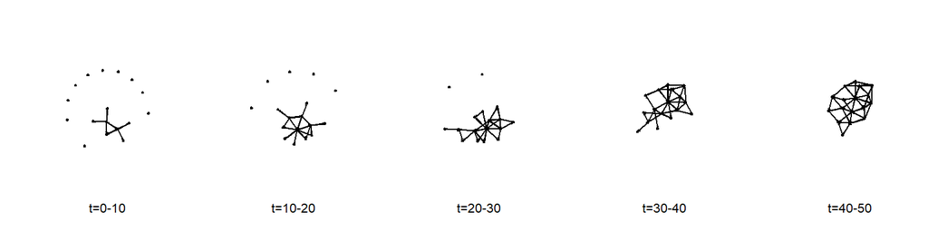

```r
filmstrip(net3.dyn, displaylabels=F, mfrow=c(1, 5),
          slice.par=list(start=0, end=49, interval=10,
                         aggregate.dur=10, rule='any'))
```

Next, let’s generate a network animation. We can pre-compute the coordinates for it (otherwise they get calculated when we generate the animation). Here `animation.mode` is the layout algorithm - one of “kamadakawai”, “MDSJ”, “Graphviz” and “useAttribute” (user-generated coordinates).

In `filmstrip()` above and in the animation computation below, `slice.par` is a list of parameters controlling how the network visualization moves through time. The parameter `interval` is the time step between layouts, `aggregate.dur` is the period shown in each layout, `rule` is the rule for displaying elements (e.g. `any`: active at any point during that period, `all`: active during the entire period, etc).

```r
compute.animation(net3.dyn, animation.mode = "kamadakawai",
                  slice.par=list(start=0, end=50, interval=1,
                         aggregate.dur=1, rule='any'))

render.d3movie(net3.dyn, usearrows = F,
       displaylabels = F, label=net3 %v% "media",
       bg="#ffffff", vertex.border="#333333",
       vertex.cex = degree(net3)/2,
       vertex.col = net3.dyn %v% "col",
       edge.lwd = (net3.dyn %e% "weight")/3,
       edge.col = '#55555599',
       vertex.tooltip = paste("<b>Name:</b>", (net3.dyn %v% "media") , "<br>",
                              "<b>Type:</b>", (net3.dyn %v% "type.label")),
       edge.tooltip = paste("<b>Edge type:</b>", (net3.dyn %e% "type"), "<br>",
                            "<b>Edge weight:</b>", (net3.dyn %e% "weight" ) ),
       launchBrowser=T, filename="Media-Network-Dynamic.html",
       render.par=list(tween.frames = 30, show.time = F),
       plot.par=list(mar=c(0,0,0,0)), output.mode='inline' )
```

[interactive chart not shown]

To embed this animation, we add the parameter `output.mode='inline'`.

In addition to dynamic nodes and edges, `ndtv` also takes dynamic attributes. We could have added those to the `es` and `vs` data frames above. However, the plotting function can also evaluate special parameters and generate dynamic arguments on the fly. For example, `function(slice) {` do some calculations with slice `}` will perform operations on the current time slice of the network, allowing us to change parameters dynamically.

See the node size below:

```r
render.d3movie(net3.dyn, usearrows = F,
       displaylabels = F, label=net3 %v% "media",
       bg="#000000", vertex.border="#dddddd",
       vertex.cex = function(slice){ degree(slice)/2.5 },
       vertex.col = net3.dyn %v% "col",
       edge.lwd = (net3.dyn %e% "weight")/3,
       edge.col = '#55555599',
       vertex.tooltip = paste("<b>Name:</b>", (net3.dyn %v% "media") , "<br>",
                              "<b>Type:</b>", (net3.dyn %v% "type.label")),
       edge.tooltip = paste("<b>Edge type:</b>", (net3.dyn %e% "type"), "<br>",
                            "<b>Edge weight:</b>", (net3.dyn %e% "weight" ) ),
       launchBrowser=T, filename="Media-Network-even-more-Dynamic.html",
       render.par=list(tween.frames = 15, show.time = F), output.mode='inline',
       slice.par=list(start=0, end=50, interval=4, aggregate.dur=4, rule='any'))
```

[interactive chart not shown]

# 8 Overlaying networks on geographic maps

The example presented in this section uses only base R and mapping packages. If you have experience with `ggplot2`, that package does provide a more versatile way of approaching this task. The code using `ggplot()` would be similar to what you will see below, but you would use `borders()` to plot the map and `geom_path()` for the edges.

In order to plot on a map, we will need a few more packages. As you will see below, `maps` will let us generate a geographic map to use as background, and `geosphere` will let us generate arcs representing our network edges. If you do not already have them, install the two packages, then load them.

```r
install.packages('maps')
install.packages('geosphere')
```

```r
library('maps')
library('geosphere')
```

Let us plot some example maps with the `maps` package. The parameters of `maps()` include `col` for the map fill, `border` for the border color, and `bg` for the background color.

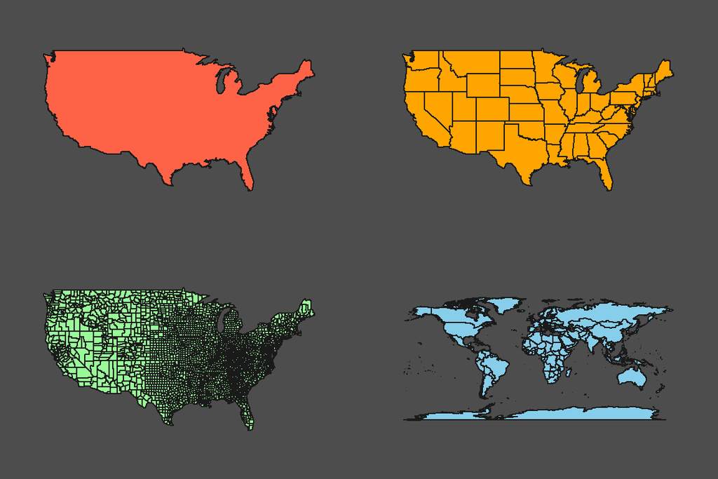

```r
par(mfrow = c(2,2), mar=c(0,0,0,0))

map("usa", col="tomato",  border="gray10", fill=TRUE, bg="gray30")
map("state", col="orange",  border="gray10", fill=TRUE, bg="gray30")
map("county", col="palegreen",  border="gray10", fill=TRUE, bg="gray30")
map("world", col="skyblue",  border="gray10", fill=TRUE, bg="gray30")
```

```r
dev.off()
```

The data we will use here contains US airports and flights among them. The airport file includes geographic coordinates - latitude and longitude. If you do not have those in your data, you can the `geocode()` function from package `ggmap` to grab the latitude and longitude for an address.

```r
airports <- read.csv("Dataset3-Airlines-NODES.csv", header=TRUE)
flights <- read.csv("Dataset3-Airlines-EDGES.csv", header=TRUE, as.is=TRUE)

head(flights)
```

```
##   Source Target Freq
## 1      0    109   10
## 2      1     36   10
## 3      1     61   10
## 4      2    152   10
## 5      3    104   10
## 6      4    132   10
```

```r
head(airports)
```

```
##   ID                     Label Code             City latitude  longitude ToFly
## 1  0       Adams Field Airport  LIT  Little Rock, AR 34.72944  -92.22444     0
## 2  1     Akron/canton Regional  CAK Akron/Canton, OH 40.91611  -81.44222     0
## 3  2      Albany International  ALB           Albany 42.73333  -73.80000     0
## 4  3                 Albemarle  CHO  Charlottesville 38.13333  -78.45000     1
## 5  4 Albuquerque International  ABQ      Albuquerque 35.04028 -106.60917     0
## 6  5  Alexandria International  AEX   Alexandria, LA 31.32750  -92.54861     0
##   Visits
## 1    105
## 2    123
## 3    129
## 4    114
## 5    105
## 6     93
```

```r
# Select only large airports: ones with more than 10 connections in the data.
tab <- table(flights$Source)
big.id <- names(tab)[tab>10]
airports <- airports[airports$ID %in% big.id,]
flights  <- flights[flights$Source %in% big.id &
                    flights$Target %in% big.id, ]
```

In order to generate our plot, we will first add a map of the United states. Then we will add a point on the map for each airport:

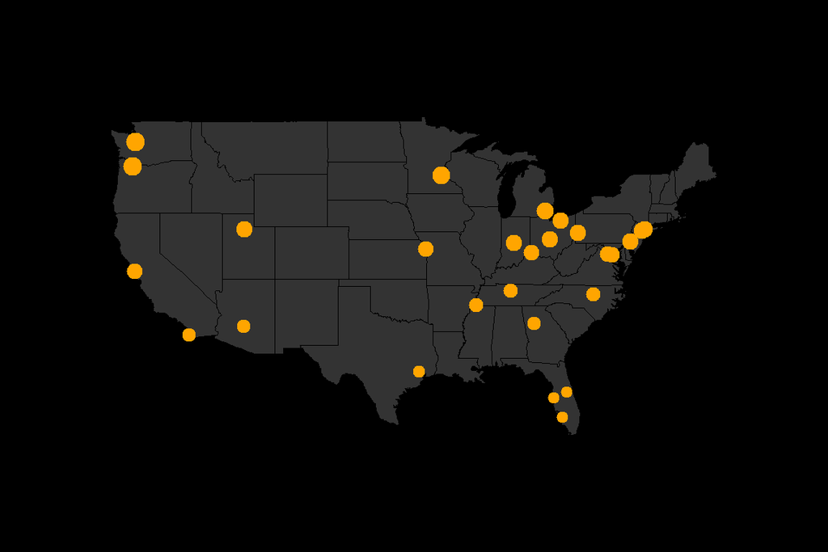

```r
# Plot a map of the united states:
map("state", col="grey20", fill=TRUE, bg="black", lwd=0.1)

# Add a point on the map for each airport:
points(x=airports$longitude, y=airports$latitude, pch=19,
       cex=airports$Visits/80, col="orange")
```

Next we will generate a color gradient to use for the edges in the network. Heavier edges will be lighter in color.

```r
col.1 <- adjustcolor("orange red", alpha=0.4)
col.2 <- adjustcolor("orange", alpha=0.4)
edge.pal <- colorRampPalette(c(col.1, col.2), alpha = TRUE)
edge.col <- edge.pal(100)
```

For each flight in our data, we will use `gcIntermediate()` to generate the coordinates of the shortest arc that connects its start and end point (think distance on the surface of a sphere). After that, we will plot each arc over the map using `lines()`.

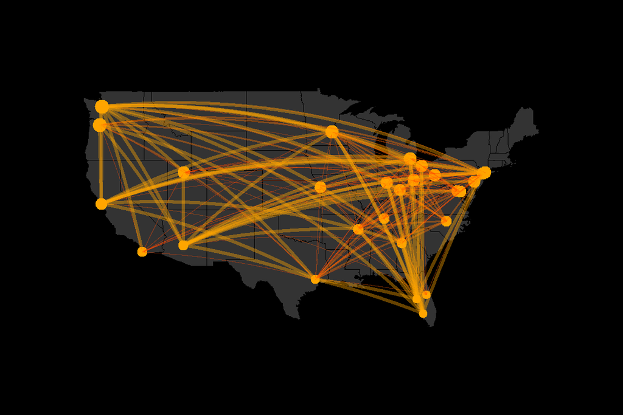

```r
for(i in 1:nrow(flights))  {
    node1 <- airports[airports$ID == flights[i,]$Source,]
    node2 <- airports[airports$ID == flights[i,]$Target,]

    arc <- gcIntermediate( c(node1[1,]$longitude, node1[1,]$latitude),
                           c(node2[1,]$longitude, node2[1,]$latitude),
                           n=1000, addStartEnd=TRUE )
    edge.ind <- round(100*flights[i,]$Freq / max(flights$Freq))

    lines(arc, col=edge.col[edge.ind], lwd=edge.ind/30)
}
```

Note that if you are plotting the network on a full world map, there might be cases when the shortest arc goes “behind” the map – e.g. exits it on the left side and enters back on the right (since the left-most and right-most points on the map are actually next to each other). In order to avoid that, we can use `greatCircle()` to generate the full [great circle](https://en.wikipedia.org/wiki/Great_circle) (circle going through those two points and around the globe, with a center at the center of the earth). Then we can extract from it the arc connecting our start and end points which does not cross “behind” the map, regardless of whether it is the shorter or the longer of the two.

This is the end of our tutorial. If you have comments, questions, or want to report typos, please e-mail rnetviz@ognyanova.net. Check for updated versions of the tutorial at kateto.net.